# Adrien HANS & Tanguy JEANNEAU

# EnsLearn - TP n°3

# A rendre pour le 6 janvier

## Exercice 1 : Boosted trees

```python
import numpy as np
import random
import matplotlib.pyplot as plt
from sklearn.preprocessing import StandardScaler
from sklearn.datasets import make_moons
from sklearn.tree import DecisionTreeClassifier
from sklearn.naive_bayes import GaussianNB
from sklearn.neighbors import KNeighborsClassifier
from sklearn.ensemble import VotingClassifier as VC
import seaborn as sns
#Pour faciliter la gestion des poids :
import pandas as pd
```

### Question 1 :

*Reprenez le même dataset qu’au TP n°1 (en fixant à 0 la seed du générateur aléatoire et toujours avec le paramètre noise fixé à 0.3). Ce dataset est généré par make_moons et contient n = 300 points de données.*

*Nous ne ferons pas ici de validation croisée.*

**Génération du dataset :**

```python
(Y,c) = make_moons(n_samples=300,noise=0.3, random_state=0) #random_state : seed du générateur
```

**Affichage du dataset :**

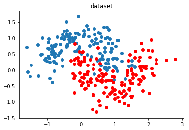

```python
plt.scatter(Y[c==0][:,0], Y[c==0][:,1])
plt.scatter(Y[c==1][:,0], Y[c==1][:,1],color='r')
plt.title('dataset')
plt.show()
```

## Question 2 :

*Transformez le classifieur faible du TP n°1 ("Bad Tree") en classifieur fort grâce à l’algorithme AdaBoost. Chaque membre du comité est donc un arbre de décision de profondeur maximale 1 (tree stump) et est une instance de DecisionTreeClassifier(max_depth=1). On prendra M = 20 classifieurs dans le comité. Pour qu’un arbre minimise la perte pondérée par les poids $w_m^{(i)}$ d’AdaBoost, vous devrez obtenir un échantillon bootstrap à partir de vos données généré en 1). Cet échantillon s’obtient en tirant au hasard une donnée avec la probabilité: $$p_i=\frac{w_m^{(i)}}{\sum_{i'=1}^nw_m^{(i')}}$$*

*On pourra utiliser `np.random.multinomial` à cette fin.*

*Comment évolue le risque empirique sur les données d’entraînement ?*

```python
#Classifieur faible :
#Arbre de décision de profondeur maximale 1
maxdepth=1
#number of classifiers :
M=20

def Adaboost(Y,c,maxdepth,M):
    n=len(c)
    #On se replace dans le cas binaire {-1,1} :
    c=np.array(c*2-1)
    alphas=[]
    models=[]
    accuracy=[]
    epsilons=[]
    c_pd = pd.DataFrame(c.copy())
    c_pd['weights'] = 1/n # On attribue les poids initiaux : w = 1/n

    for k in range(1, M+1):
        predictions=[]
        #Sampler un dataset :
        #Il faut prendre la taille = 4*n
        Dboost=np.random.multinomial(n=n,pvals=(c_pd['weights']/(c_pd['weights'].sum())),size=4).reshape(4*n)
        #On définit Yboost :
        Yboost=np.array([Y[i] for i in Dboost]).reshape(4*n,2)
        #On définit les classes associées cboost :
        cboost=np.array([c[i] for i in Dboost])
        cboost_pd = pd.DataFrame(cboost.copy())
        cboost_pd['weights'] = [c_pd['weights'][i] for i in Dboost]


        #On défnit l'arbre :
        DTC = DecisionTreeClassifier(max_depth=maxdepth)
        #On entraine l'arbre :
        model=DTC.fit(Y,c, sample_weight=np.array(c_pd['weights']))
        #On stock le modèle :
        models.append(model)
        #Prediction du model :
        c_pred=model.predict(Y)
        #On calcule epsilon:
        c_pd['misclassified'] = np.where(c_pred != c ,1,0)
        epsilon = np.sum(c_pd['weights']*c_pd['misclassified'])/np.sum(c_pd['weights'])
        #On calcule alpha:
        alpha=np.log((1-epsilon)/epsilon)
        alphas.append(alpha)
        #Mise à jour du poids :
        c_pd['weights'] = c_pd['weights']*np.exp(-0.5*alpha*c_pred*c)

    return alphas, models

def Adaboost_predict(alphas, models, Y):
    predictions=[]
    for alpha, model in zip(alphas, models):
        # We use the predict method for the single decisiontreeclassifier models in the list
        prediction = alpha*model.predict(Y)
        predictions.append(prediction)

    #On fait la prediction finale :
    final_pred=np.sign(np.sum(np.array(predictions), axis=0))
    return final_pred

def Adaboost_accuracy(alphas, models, Y, c):
    accuracy=[]
    n=len(c)
    #On se replace dans le cas binaire {-1,1} :
    c=np.array(c*2-1)
    M=len(models)
    for i in range(M):
        final_pred=Adaboost_predict(alphas[:i+1], models[:i+1], Y)
        accuracy.append(np.sum(np.array(final_pred)==c)/(n))
    return accuracy
```

```python
alphas, models=Adaboost(Y,c,maxdepth,M)
accuracy=Adaboost_accuracy(alphas, models, Y, c)
```

**On affiche l'évolution du risque empirique sur les données d'entrainement :**

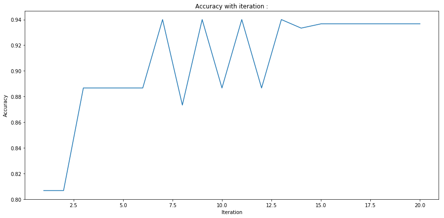

```python
fig=plt.figure(figsize=(15,7))
plt.plot([k for k in range(1,M+1)], accuracy)
plt.xlabel('Iteration')
plt.ylabel('Accuracy')
plt.title('Accuracy with iteration :')
plt.show()
```

**Même si certaines oscillations peuvent être présentes, plus le nombre de classifieurs dans le comité est important meilleurs sont les résultats de classification.**

**Ce résultat était évidemment attendu et justifie l'utilisation d'une telle méthode.**

### Question 3 :

*Générez un autre dataset de même taille que précédemment mais en changeant la seed.*

*Comment évolue le risque empirique sur ces données de test ?*

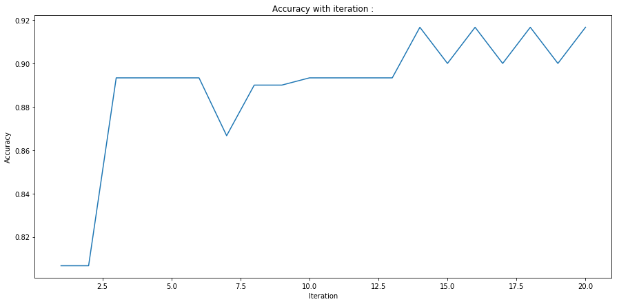

```python
#Génération du dataset :
(Y,c) = make_moons(n_samples=300,noise=0.3, random_state=6) #random_state : seed du générateur

maxdepth=1
M=20
alphas, models = Adaboost(Y,c,maxdepth,M)
accuracy=Adaboost_accuracy(alphas, models, Y, c)

fig=plt.figure(figsize=(15,7))
plt.plot([k for k in range(1,M+1)], accuracy)
plt.xlabel('Iteration')
plt.ylabel('Accuracy')
plt.title('Accuracy with iteration :')
plt.show()
```

**A l'instar des résultats obtenus sur le dataset précédent -avec une seed différente- malgré de légères oscillations, plus il y a de classifieurs dans le comité, meilleures les résultats sont, avec donc un maximum de bonne classification lorsque le nombre de classifieurs est maximal et égal à 20.**

**Essai avec plus de M=20 classifieurs dans le comité :**

**Par exemple avec M=200:**

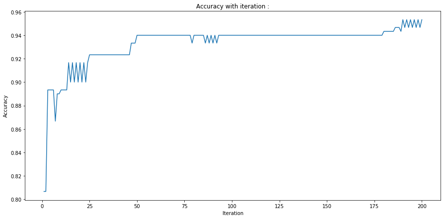

```python
#Génération du dataset :
(Y,c) = make_moons(n_samples=300,noise=0.3, random_state=6) #random_state : seed du générateur

maxdepth=1
M=200
alphas, models = Adaboost(Y,c,maxdepth,M)
accuracy=Adaboost_accuracy(alphas, models, Y, c)

fig=plt.figure(figsize=(15,7))
plt.plot([k for k in range(1,M+1)], accuracy)
plt.xlabel('Iteration')
plt.ylabel('Accuracy')
plt.title('Accuracy with iteration :')
plt.show()
```

**On observe comme prévu qu'avec plus de classifieurs dans le comité les résultats sont encore meilleurs que ceux obtenus précédemment.**

### question 4 :

*Affichez l’évolution du comité au fil des itérations d’AdaBoost ainsi que les arbres successivement appris.*

**Nous implementons maintenant les fonctions `frontieres` et `frontieres_Adaboost` permettant d'afficher les resultats, que nous utilisons ensuite.**

```python
def frontieres(clf, X=Y):
    h = .02
    x1_min, x1_max = X[:, 0].min() - .5, X[:, 0].max() + .5
    x2_min, x2_max = X[:, 1].min() - .5, X[:, 1].max() + .5
    x11, x22 = np.meshgrid(np.arange(x1_min, x1_max, h),np.arange(x2_min, x2_max, h))
    if hasattr(clf, "decision_function"):
        Z = clf.decision_function(np.c_[x11.ravel(), x22.ravel()])
    else:
        Z = clf.predict(np.c_[x11.ravel(), x22.ravel()])
    Z=Z.reshape(x11.shape)
    plt.contourf(x11, x22, Z, cmap=plt.cm.bwr, alpha=.8)
```

```python
def frontieres_Adaboost(alphas, models, X=Y):
    h = .02
    x1_min, x1_max = X[:, 0].min() - .5, X[:, 0].max() + .5
    x2_min, x2_max = X[:, 1].min() - .5, X[:, 1].max() + .5
    x11, x22 = np.meshgrid(np.arange(x1_min, x1_max, h),np.arange(x2_min, x2_max, h))
    Z = Adaboost_predict(alphas, models, np.c_[x11.ravel(), x22.ravel()])
    Z=Z.reshape(x11.shape)
    plt.contourf(x11, x22, Z, cmap=plt.cm.bwr, alpha=.8)
```

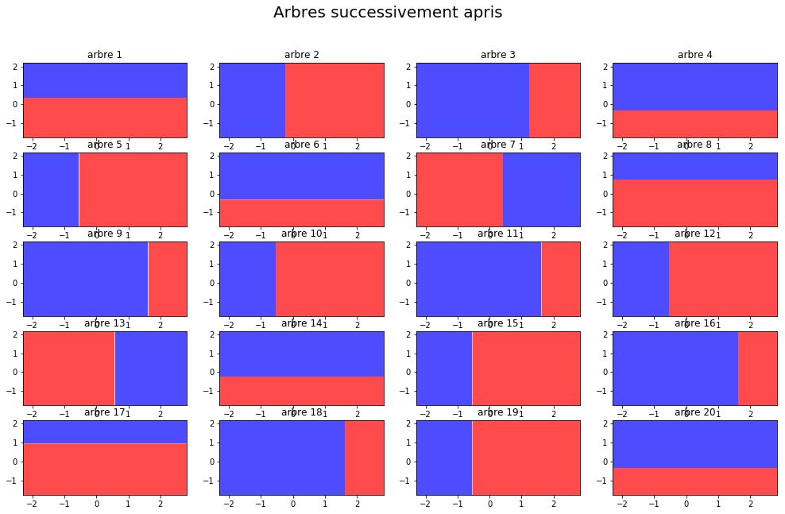

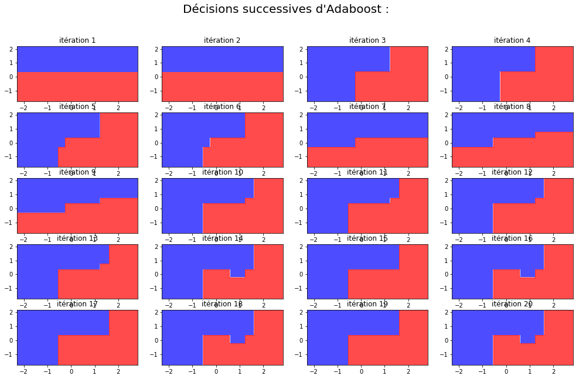

```python
#Génération du dataset :
(Y,c) = make_moons(n_samples=300,noise=0.3, random_state=6) #random_state : seed du générateur

maxdepth=1
M=20
alphas, models = Adaboost(Y,c,maxdepth,M)
accuracy=Adaboost_accuracy(alphas, models, Y, c)


fig=plt.figure(figsize=(17,10))
fig.suptitle('Arbres successivement apris', size=20)
for i in range(M):
    plt.subplot(5,4,i+1)
    plt.title('arbre %i' %(i+1))
    frontieres(models[i], Y)

fig=plt.figure(figsize=(17,10))
fig.suptitle("Décisions successives d'Adaboost :", size=20)
for i in range(M):
    plt.subplot(5,4,i+1)
    plt.title('itération %i' %(i+1))
    frontieres_Adaboost(alphas[:i+1], models[:i+1], Y)
```

**On observe bien les frontières de décision associées à chaque arbre et associées à chaque étape de l'algorithme Adaboost.**

**On observe plusieurs occurences de certaines de ces frontières au fur et à mesures des itérations de l'algorithme.**

## Exercice 2 : Stacked NBCs

*Dans cet exercie, chaque classifieur de base verra des données appartenant à une région spécifique de l’input space. Les classifieurs de base n’auront donc pas accès à un dataset i.i.d. Le classifieur de second niveau aura lui accès à 20% de chaque dataset local. L’union de ces fractions de datasets constituera un échantillon i.i.d. permettant au comité d’obtenir de bonnes performances globales.*

*On considérera qu’un classifieur choisit une unique classe : fm (x) ∈ C où C est l’ensemble des classes. On fixe la taille du comité à M = 4. Le classifieur de second niveau sera aussi un Naive Bayes Classifier (NBC), mais ce dernier s’appuiera sur une distribution multinomiale. Pour les classifieur de premier niveau, la distribution sous-jacente sera Gaussienne car les inputs x sont des vecteurs de $R^2$*.

*Nous utiliserons les implémentations du NBC fournies par le module `sklearn`.*

### Question 1 :

*Mettez en préambule de votre code les instructions suivantes :*

```python
import numpy as np
import matplotlib.pyplot as plt
from sklearn.datasets import make_blobs
from sklearn.naive_bayes import GaussianNB, MultinomialNB

from sklearn.model_selection import train_test_split
import seaborn as sns
```

### Question 2 :

*Nous allons commencer par générer le dataset synthétique qui nous servira de terrain de jeu pour cet exercice. Pour ce faire, vous appellerez la fonction `gen_blobs` fourni par l’enseignant. Vous spécifierez la taille souhaitée pour le dataset en argument de cette fonction, à savoir n = 300.*

**Fonction `gen_blobs` :**

```python
def gen_blobs(n, beta=0.5, random_state=None):
    """
    This function generates a dataset from the following generating process:
    4 gaussian 2D distributions centered on each corner of a centered square
    whose side length is 4. Each gaussian has unit variance
    The diagonal blobs generates example of class n° 0. The anti-diagonal blobs
    generates examples of class n°1 and n°2 respectively.
    """
    X1, y1 = make_blobs(shuffle=False,n_samples=int(n*beta),n_features=2, centers=np.asarray([[-1.5,-1.5],[-1.5,1.5] ]), random_state=random_state)
    X2, y2 = make_blobs(shuffle=False,n_samples=int(n*(1-beta)),n_features=2, centers=np.asarray([[-1.5,-1.5],[-1.5,1.5] ]), random_state=random_state)
    X3, y3 = make_blobs(shuffle=False,n_samples=int(n*beta),n_features=2, centers=np.asarray([[1.5,1.5],[1.5,-1.5] ]), random_state=random_state)
    X4, y4 = make_blobs(shuffle=False,n_samples=int(n*(1-beta)),n_features=2, centers=np.asarray([[1.5,1.5],[1.5,-1.5] ]), random_state=random_state)
    X = np.vstack((X1[np.where(y1==0)],X2[np.where(y2==1)],X3[np.where(y3==0)],X4[np.where(y4==1)]))
    y = np.hstack((y1[np.where(y1==0)],y2[np.where(y2==1)],y3[np.where(y3==0)],y4[np.where(y4==1)]))
    perm = np.random.permutation(len(y))
    X = X[perm]
    y = y[perm]
    return (X,y)
```

**Génération du dataset :**

```python
(Y,c) = gen_blobs(300, random_state=None)
```

**Affichage du dataset :**

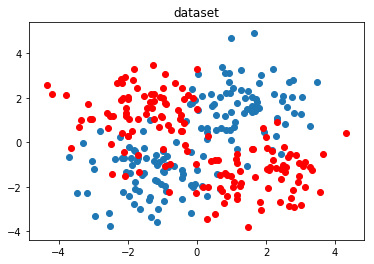

```python
plt.scatter(Y[c==0][:,0], Y[c==0][:,1])
plt.scatter(Y[c==1][:,0], Y[c==1][:,1],color='r')
plt.title('dataset')
plt.show()
```

### Question 3 :

**On prend 20% du dataset pour le classfieur de second niveau :**

```python
#(Y2,c2) correspond au classifieur de second niveau
Y1, Y2, c1, c2 = train_test_split(Y, c, train_size=0.80, random_state=42)
```

**On sépare les 80% restants :**

```python
#On prend la moyenne des deux axes :
m0=np.mean(Y[:,0])
m1=np.mean(Y[:,1])


dataset1=Y1[(Y1[:,0]<m0) | (Y1[:,1]<m1)]
c11=c1[(Y1[:,0]<m0) | (Y1[:,1]<m1)]

dataset2=Y1[(Y1[:,0]>m0) | (Y1[:,1]<m1)]
c12=c1[(Y1[:,0]>m0) | (Y1[:,1]<m1)]

dataset3=Y1[(Y1[:,0]<m0) | (Y1[:,1]>m1)]
c13=c1[(Y1[:,0]<m0) | (Y1[:,1]>m1)]

dataset4=Y1[(Y1[:,0]>m0) | (Y1[:,1]>m1)]
c14=c1[(Y1[:,0]>m0) | (Y1[:,1]>m1)]

Datasets=[[dataset1,c11], [dataset2,c12], [dataset3,c13], [dataset4,c14]]
```

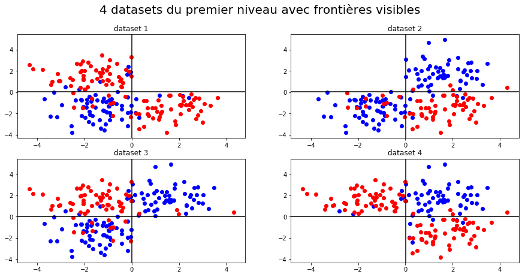

```python
#On prend les minimums et maximums du dataset pour permettre un affichage uniforme :
x1_min, x1_max = Y[:, 0].min() - .5, Y[:, 0].max() + .5
x2_min, x2_max = Y[:, 1].min() - .5, Y[:, 1].max() + .5

fig=plt.figure(figsize=(15,7))
fig.suptitle('4 datasets du premier niveau avec frontières visibles', size=20)
for i in range(4):
    plt.subplot(2,2,i+1)
    dataset=Datasets[i][0]
    c=Datasets[i][1]
    plt.scatter(dataset[c==0][:,0], dataset[c==0][:,1], color='blue')
    plt.scatter(dataset[c==1][:,0], dataset[c==1][:,1],color='r')
    plt.hlines(m1,x1_min,x1_max)
    plt.vlines(m0,x2_min,x2_max)
    plt.xlim((x1_min,x1_max))
    plt.ylim((x2_min,x2_max))
    plt.title('dataset %i'%(i+1))
plt.show()
```

**On note bien que les datasets locaux ne sont pas disjoints.**

### Question 4 :

*Instanciez quatre NBCs en appelant le constructeur de la classe `GaussianNB()`. Vous entraînerez ces classifieurs en appelant la méthode fit de cette même classe (attention à fournir les quatre datasets locaux différents)*

```python
models=[]
for i in range(4):
    GNB=GaussianNB()
    GNB.fit(Datasets[i][0], Datasets[i][1])
    models.append(GNB)
```

### Question 5 :

*En vous appuyant sur le 1er TP, affichez les frontières de décision vers lesquelles vos classifieurs ont convergé*

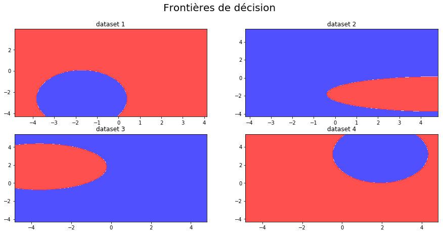

```python
fig=plt.figure(figsize=(15,7))
fig.suptitle('Frontières de décision', size=20)
for i in range(4):
    plt.subplot(2,2,i+1)
    plt.title('dataset %i' %(i+1))
    frontieres(models[i], Datasets[i][0])
```

**Nous obtenons bien des résultats très proches de ceux prévus.**

### Question 6:

*Construisez des vecteurs c de taille 4, tels que cm = fm (x), où l’input x est un vecteur des 20% de données mises de côté. Instanciez un NBC en appelant le constructeur de la classe MultinomialNB() que vous entraînerez grâce aux vecteurs c et leurs étiquettes associées y.*

```python
def vector_C(models=models, Y2=Y2, c2=c2):
    #chaque ligne de C correspond un vecteur c tel que définit plus haut
    C=np.array([model.predict(Y2) for model in models]).T
    model_MNB=MultinomialNB()
    model_MNB.fit(C, c2)
    return C, model_MNB
```

### Question 7 :

*Générez un ensemble de test de même taille que celui initial (n = 300) et calculez les scores de classifications obtenus par les quatre classifieurs ainsi que par le comité.*

```python
(Y,c) = gen_blobs(300, random_state=5)

def Scores_clf_comite(models,Y, c):
    Scores=[]
    for i in range(4):
        model=models[i]
        Scores.append(model.score(Y,c))

    C, model_MNB=vector_C(models, Y,c)
    Scores.append(model_MNB.score(C,c))
    return Scores
```

**On affiche les scores des 4 classifieurs et du comité :**

```python
Scores=Scores_clf_comite(models, Y, c)
for i in range(4):
    print('classifieur {i} : {result}'.format(i=i+1,result=Scores[i]))
print('Score du comité : {result:.2f}'.format(result=Scores[4]))
```

```
classifieur 1 : 0.6733333333333333
classifieur 2 : 0.6833333333333333
classifieur 3 : 0.69
classifieur 4 : 0.7
Score du comité : 0.87
```

**On observe que le score du comité est bien supérieur à chacun des scores des quatre classifieurs, ce qui est satisfaisant et montre que cette méthode fonctionne.**

### Question 8 :

*Empaquetez cette procédure dans une boucle comprenant 200 tours. Vous sauvegarderez les scores obtenus à chaque tour de boucle. Comme nous utilisons un dataset synthétique, nous pouvons générer autant de données que voulu et évaluer finement les performances sans passer par une cross-validation qui est le meilleur outil pour des données réelles en quantité finie.*

*Pour bien comprendre que le score d’un classifieur est une variable aléatoire, vous tracerez leur distributions empiriques (histogrammes) à l’aide de la fonction `plt.violinplot`.*

```python
nb_tours=200
Scores=[]
for i in range(nb_tours):
    (Y,c) = gen_blobs(300, random_state=np.random.randint(1000))
    scores=Scores_clf_comite(models, Y, c)
    Scores.append(scores)
Scores=np.array(Scores)
#Pour avoir le nom sous chaque affichage :
Scores_pd=pd.DataFrame(Scores)
Scores_pd.columns=['classifieur 1','classifieur 2','classifieur 3', 'classifieur 4', 'comite']
```

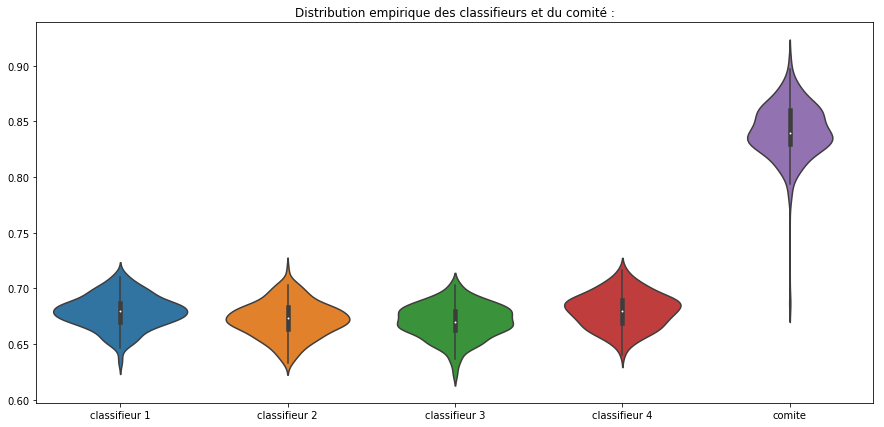

```python
fig=plt.figure(figsize=(15,7))
plt.title('Distribution empirique des classifieurs et du comité :')
sns.violinplot(data=Scores_pd)
plt.show()
```

**Comme attendu, les scores du comité sont bien plus importants que ceux obtenus par chacun des quatre classifieurs.**